# Análise Epidemiológica da Sífilis Gestacional em Alagoas, 2010-2022

Levi de Melo Amorim Graduando em Medicina Universidade Federal de Alagoas (FAMED/UFAL)

08 de maio de 2025

# Introdução

Este relatório apresenta uma análise epidemiológica dos casos de sífilis gestacional notificados no estado de Alagoas, Brasil, durante o período de 2010 a 2022. A sífilis gestacional continua sendo um importante problema de saúde pública devido ao seu potencial de transmissão vertical, resultando em sífilis congênita com graves consequências para o recém-nascido.

O objetivo deste estudo é descrever o perfil epidemiológico dos casos de sífilis gestacional, avaliar aspectos do diagnóstico e tratamento, e identificar potenciais fatores associados, utilizando dados do Sistema de Informação de Agravos de Notificação (SINAN) disponibilizados pelo DATASUS.

# Metodologia

## Fonte de Dados e População do Estudo

Foram utilizados dados secundários de domínio público do SINAN referentes à sífilis em gestantes (SIFG) para o estado de Alagoas, compreendendo notificações realizadas entre 2010 e 2022. O banco de dados foi processado e traduzido utilizando scripts em R, incluindo a padronização de códigos municipais para o formato de 7 dígitos do IBGE.

## Variáveis Analisadas

As variáveis incluídas na análise foram:

- **Características sociodemográficas:** idade materna, raça/cor, escolaridade.
- **Características da gestação e pré-natal:** idade gestacional no momento do diagnóstico.
- **Características clínicas e laboratoriais:** classificação clínica da sífilis, resultados de testes treponêmicos e não treponêmicos (VDRL).
- **Tratamento:** esquema terapêutico da gestante e tratamento do(s) parceiro(s) sexual(is).
- **Informações temporais e espaciais:** ano da notificação, município de notificação e residência.

## Análise dos Dados

A análise descritiva foi realizada por meio de frequências absolutas e relativas para variáveis categóricas, e medidas de tendência central e dispersão para variáveis numéricas. Tendências temporais foram avaliadas por meio de gráficos anuais do número de casos.

Para a análise de adequação do tratamento da gestante, foi criada uma variável `TRAT_GESTANTE_ADEQUADO` com base no esquema terapêutico (`TPESQUEMA`) registrado e na classificação clínica da sífilis (`TPEVIDENCI`), seguindo uma interpretação simplificada das diretrizes do Ministério da Saúde do Brasil. As premissas para esta classificação são: * **Sífilis Primária, Secundária ou Latente Recente (assumida para ‘Latente’ não especificada):** tratamento adequado com Penicilina G Benzatina 2.400.000 UI (dose única). * **Sífilis Terciária ou Latente Tardia (ou Latente com duração ignorada onde esta distinção é feita):** tratamento adequado com Penicilina G Benzatina 7.200.000 UI (total, 3 doses semanais). * Qualquer registro de “Não realizado”, “Ignorado” ou “Outro esquema” (sem especificação de ser adequado) em `TPESQUEMA` foi considerado inadequado ou não tratado. * Se `TPEVIDENCI` for “Ignorado”, a adequação não pode ser avaliada confiavelmente e é classificada como “Indeterminada”.

Foi realizada uma análise de regressão logística multivariada para identificar fatores associados ao tratamento inadequado da gestante. As Odds Ratios (OR) ajustadas e seus respectivos intervalos de confiança de 95% (IC95%) foram calculados.

Todas as análises foram conduzidas utilizando o software R versão 4.4.1 e os pacotes `tidyverse`, `gtsummary`, `finalfit`, entre outros. Tabelas e gráficos foram gerados e exportados para a subpasta `/relatorio`.

# Resultados

## 1. Perfil Geral dos Casos e Qualidade dos Dados

No período de 2010 a 2022, foram notificados 6.648 casos de sífilis gestacional em Alagoas.

Principais variáveis com dados ausentes.

| Variável | Nº Ausentes | % Ausente |
| --- | --- | --- |
| SEM_DIAG | 6648 | 100,0% |
| CLASSI_FIN | 6648 | 100,0% |
| DSMOTIVO | 5824 | 87,6% |
| TPMOTPARC | 4054 | 61,0% |
| ID_OCUPA_N | 2898 | 43,6% |
| TPESQPAR | 2090 | 31,4% |
| DSTITULO1 | 2020 | 30,4% |
| DSTITULO1_numeric | 2020 | 30,4% |
| TRATPARC | 1917 | 28,8% |
| DTTESTE1 | 1870 | 28,1% |
| CS_ESCOL_N | 719 | 10,8% |
| NOME_MUNICIP_PRENATAL | 654 | 9,8% |
| PRE_MUNIRE | 648 | 9,7% |
| PRE_UFREL | 559 | 8,4% |
| NOME_UF_PRENATAL | 559 | 8,4% |

## 2. Epidemiologia Descritiva

### 2.1. Distribuição por Características Pessoais

| **Characteristic** | **N = 6,648**<sup>1</sup> |
| --- | --- |
| Idade Materna (anos) | 23.8 (6.4) \| 22.0 (19.0, 28.0) \| 10.0, 49.0 |
| Raça/Cor Autodeclarada |  |
| 1-Branca | 775 (11.7%) |
| 2-Preta | 780 (11.7%) |
| 3-Amarela | 87 (1.3%) |
| 4-Parda | 4,526 (68.1%) |
| 5-Indígena | 29 (0.4%) |
| 9-Ignorado | 451 (6.8%) |
| Nível de Escolaridade |  |
| 0-Analfabeto | 164 (2.8%) |
| 1-EF Incompleto(1-4) | 683 (11.5%) |
| 2-EF Completo(4) | 366 (6.2%) |
| 3-EF Incompleto(5-8) | 1,534 (25.9%) |
| 4-EF Completo | 490 (8.3%) |
| 5-EM Incompleto | 682 (11.5%) |
| 6-EM Completo | 746 (12.6%) |
| 7-Superior Incompleto | 42 (0.7%) |
| 8-Superior Completo | 41 (0.7%) |
| 9-Ignorado | 1,181 (19.9%) |
| Ignorado/Ausente | 719 |
| Idade Gestacional no Diagnóstico |  |
| 1-1ºTrimestre | 1,734 (26.1%) |
| 2-2ºTrimestre | 2,206 (33.2%) |
| 3-3ºTrimestre | 2,437 (36.7%) |
| 4-Idade gestacional ignorada | 271 (4.1%) |
| Classificação Clínica da Sífilis |  |
| 1-Primária | 2,049 (30.8%) |
| 2-Secundária | 446 (6.7%) |
| 3-Terciária | 715 (10.8%) |
| 4-Latente | 1,357 (20.4%) |
| 9-Ignorado | 2,081 (31.3%) |

<sup>1</sup> Mean (SD) | Median (Q1, Q3) | Min, Max; n (%)

A idade média das gestantes foi de 23.8 anos (DP: 6.4), variando de 10 a 49 anos. A raça/cor predominante foi a parda. Quanto à escolaridade, observa-se uma concentração nos níveis fundamental incompleto e médio incompleto, além de uma proporção considerável de dados ignorados/ausentes. O diagnóstico ocorreu predominantemente no segundo e terceiro trimestres gestacionais. Em relação à classificação clínica, uma parcela significativa foi classificada como “Ignorado”.

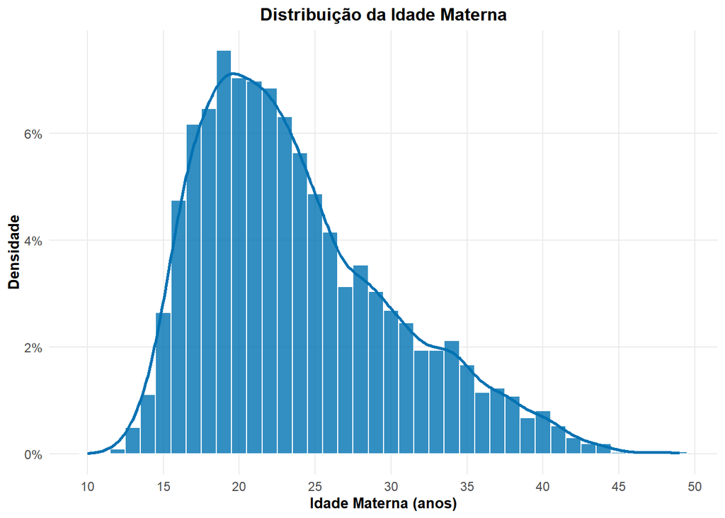

Distribuição da idade materna dos casos de sífilis gestacional, Alagoas, 2010-2022.

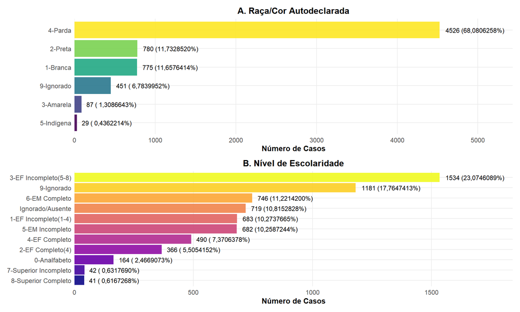

Distribuição dos casos por Raça/Cor e Escolaridade, Alagoas, 2010-2022.

### 2.2. Distribuição Temporal

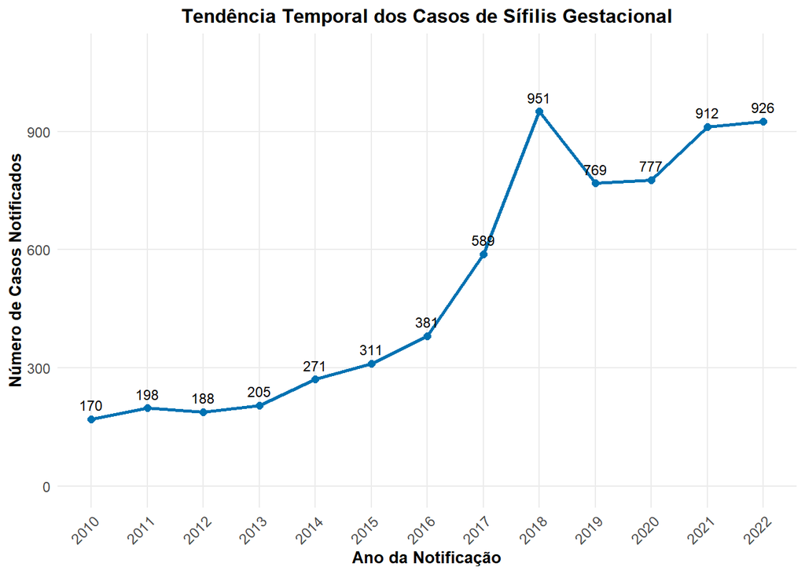

Número de casos notificados de sífilis gestacional por ano, Alagoas, 2010-2022.

Observa-se um aumento expressivo no número de casos notificados de sífilis gestacional em Alagoas ao longo do período analisado, especialmente a partir de 2017. Este aumento pode refletir uma combinação de fatores, incluindo a real elevação da incidência, a expansão da testagem durante o pré-natal e a melhoria do sistema de vigilância epidemiológica.

### 2.3. Distribuição Espacial

Dez principais municípios de residência por número de casos.

| Município de Residência | Número de Casos |
| --- | --- |
| Maceió | 2754 |
| Rio Largo | 221 |
| Arapiraca | 212 |
| Marechal Deodoro | 199 |
| Penedo | 167 |
| Maragogi | 161 |
| Atalaia | 148 |
| Pilar | 132 |
| União Dos Palmares | 113 |
| Palmeira Dos Índios | 110 |

A capital, Maceió, concentra a maior parte dos casos de residência, seguida por outros municípios populosos do estado. A análise de taxas de incidência por município seria necessária para uma avaliação mais precisa do risco em cada localidade, o que demandaria dados populacionais específicos.

## 3. Avaliação do Diagnóstico e Tratamento

### 3.1. Diagnóstico Laboratorial

| **Characteristic** | **N = 6,648**<sup>1</sup> |
| --- | --- |
| Teste Não Treponêmico (VDRL/RPR) |  |
| 1-Reagente | 4,628 (69.6%) |
| 2-Não reagente | 154 (2.3%) |
| 3-Não realizado | 887 (13.3%) |
| 9-Ignorado | 979 (14.7%) |
| Teste Confirmatório (FTA-Abs, etc.) |  |
| 1-Reagente | 4,537 (68.2%) |
| 2-Não reagente | 229 (3.4%) |
| 3-Não realizado | 1,419 (21.3%) |
| 9-Ignorado | 463 (7.0%) |

<sup>1</sup> n (%)

A maioria dos casos (69,61492%) teve teste não treponêmico reagente. No entanto, uma parcela considerável (13,34236%) não realizou este teste inicial ou o resultado foi ignorado (14,72623%). Similarmente, para o teste confirmatório, embora 68,24609%% tenham sido reagentes, 21,34477%% não o realizaram, o que representa uma falha na confirmação diagnóstica preconizada.

### 3.2. Adequação do Tratamento da Gestante

Para avaliar a adequação do tratamento, foi criada a variável `TRAT_GESTANTE_ADEQUADO` com base no esquema terapêutico (`TPESQUEMA`) e na classificação clínica (`TPEVIDENCI`), conforme detalhado na Metodologia.

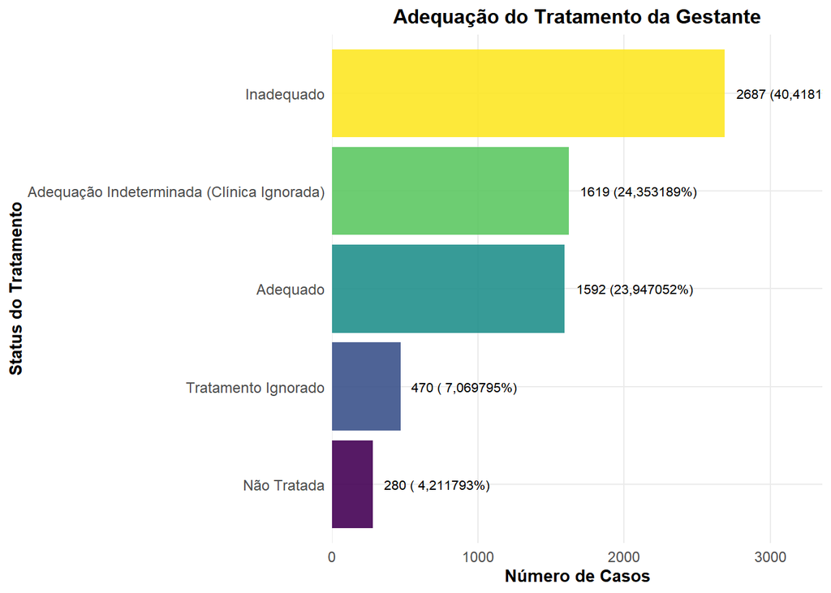

Adequação do tratamento da sífilis gestacional, Alagoas, 2010-2022.

### 3.3. Tratamento do Parceiro

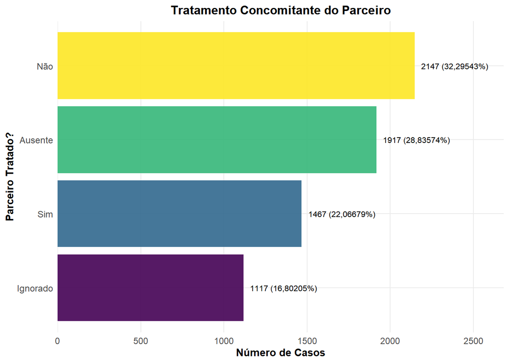

Status do tratamento do(s) parceiro(s) sexual(is), Alagoas, 2010-2022.

## 4. Epidemiologia Analítica

### 4.1. Fatores Associados ao Tratamento Inadequado/Não Tratamento da Gestante

Foi ajustado um modelo de regressão logística multivariada para investigar fatores associados à variável `TRAT_ADEQUADO_BIN` (Adequado vs. Inadequado/Não Tratado). Foram incluídas no modelo as variáveis: faixa etária (categorizada), raça/cor, escolaridade, classificação clínica da sífilis materna, idade gestacional no diagnóstico e ano da notificação.

### Tabela de Regressão Logística Multivariada

[output not shown]

Abbreviations: CI = Confidence Interval, OR = Odds Ratio

### Forest Plot dos Odds Ratios Ajustados

[figure not shown]

Forest Plot: Fatores Associados ao Tratamento Inadequado/Não Tratamento da Gestante.

# Discussão

O perfil sociodemográfico das gestantes acometidas aponta para vulnerabilidades, com destaque para a ocorrência em adolescentes e adultas jovens, e uma concentração em estratos de menor escolaridade. Esses achados são consistentes com a literatura nacional e internacional, que frequentemente associa a sífilis a condições de vulnerabilidade social.

A avaliação do diagnóstico e tratamento evidenciou falhas importantes. A não realização de testes confirmatórios em uma parcela dos casos e, crucialmente, a alta proporção de tratamento materno inadequado ou não realizado, bem como a baixa cobertura de tratamento dos parceiros, são pontos críticos que comprometem diretamente os esforços para a eliminação da sífilis congênita. A definição de adequação do tratamento utilizada neste relatório, embora simplificada, sugere que as diretrizes terapêuticas podem não estar sendo seguidas à risca em muitos casos.

**Limitações do Estudo:** Este estudo possui limitações inerentes ao uso de dados secundários, como a qualidade do preenchimento das fichas de notificação e a ausência de algumas variáveis importantes (ex: momento exato do tratamento em relação ao parto, detalhes sobre “outro esquema” de tratamento). A definição de adequação do tratamento foi baseada nas informações disponíveis e pode não capturar toda a complexidade clínica. A ausência de dados populacionais detalhados por município e ano limitou a análise espacial a contagens absolutas.

# Conclusão

A sífilis gestacional permanece um desafio significativo para a saúde pública em Alagoas. Apesar dos avanços na testagem e notificação, persistem falhas críticas no manejo adequado dos casos, especialmente no que tange à completude do esquema terapêutico da gestante e ao tratamento dos parceiros.

Recomenda-se o fortalecimento das ações de vigilância epidemiológica, a qualificação contínua dos profissionais de saúde para o diagnóstico e tratamento oportunos e adequados da sífilis gestacional conforme os protocolos vigentes, e a intensificação das estratégias de busca e tratamento de parceiros sexuais. A melhoria da qualidade dos registros no SINAN também é fundamental para monitorar e avaliar as intervenções.

# Referências